# Time Series

CK

# 介绍

## 时间序列分析：

- 一个时间序列由在连续递增的时间上对数据的收集、重新排序和观察组成。
- 时间间隔相等：时、日、月、季度、周年等
- 时间序列的数据是有序的，不像回归，这里数据的顺序很关键
- 注意，时间是有方向的，如果过去能够影响将来，那么观察值就不是相互独立的。

## 研究方法

- head(data.df, 5)/tail 查看变量、值的类型
- pairs20x(data.df[,2:5]) 为数据帧绘制直方图（对角线）和散点图（右上角）
- 没有把时间放进去研究的时候
- plot(data.df, which = 1) 查看残值分布，constant and with no trend
- normcheck(lm.fit)
- cooks20x(lm.fit) no influential outlier
- 由于曲线弯曲，所以log是试试
- refit.fit = lm(log(y)~x, data.df)
- summary(lm.fit)
- 查看残值随自变量的分布趋势
- 把时间放进去一起研究的时候残值图看起来更像随机分布在0附近了。可见年顺序在时间序列分析中的作用。

## 时间序列的数据结构

- 随着时间记录下来的响应变量值
- 以及一系列在同样时间点记录下来的解释变量（表示为：$X_{t1},X_{t2},X_{t3},...,X_{tk},$)
  - 我们将用它们解释相应变量的行为，或者预测相应变量未来的值。
- 在金融和经济领域，我们通常关心股票市场、消费价格等随时间的变化。
- 这类变量的观察值常常以指数形式出现：
  - 消费价格指数 CPI
  - 交易权重指数 TWI
  - 股指 NZSX50
- 附带解释变量的观察值  
  $时间段 \quad 观察值 \quad 解释变量$  
  $\quad 1 \qquad Y_1 \qquad X_{11} \quad X_{12} \quad \cdots \quad X_{1k}$  
  $\quad 2 \qquad Y_2 \qquad X_{21} \quad X_{22} \quad \cdots \quad X_{2k}$  
  $\quad \vdots \qquad \vdots \qquad \quad \vdots \qquad \vdots \quad \; \vdots \qquad \vdots$  
  $\quad t \qquad Y_t \; \qquad X_{t1} \; \quad X_{t2} \quad \cdots \quad X_{tk}$  
  $\quad \vdots \qquad \vdots \qquad \quad \vdots \qquad \vdots \quad \; \vdots \qquad \vdots$  
  $\quad T \qquad Y_T \qquad X_{T1} \quad X_{T2} \quad \cdots \quad X_{Tk}$
- 这里多了一列时间，它的顺序必须是升序排列

## 时间序列的成分

### 四个成分

1. 趋势成分：  
   最慢的成分，我们的问题是：这个趋势是上升的还是下降的？
   - 最慢、长期、平滑
   - 趋势通常来自总体的增长、变化、技术性的改变等等。
   - 趋势可以随着时间或者在一段时间内，上升或下降。
2. 周期成分： 不规则波浪形行的模式可以出现在不同的时间间隔，并且每次出现都不一样。
   - 第二慢，周期性的，一系列波浪形的
   - 循环的波长和振幅既不固定也无法预测，所以是不规则的模式
   - 很多时间序列的周期性行为主要来自商业周期 注：如果趋势成分允许非线性，则很难区分趋势成分和周期（循环）成分，这样他们就可以合并成一个趋势成分。
3. 季节成分： 规则重复的模式，有固定长度的时间间隔，例如周年或者月。
4. 随机成分(余数)  
   无法预测的随机变化 *denote: 很难区分趋势和循环成分，下面一律将它们合并成趋势成分*

在为时间序列数据建模的时候，分解成四个成分可以帮助理解和量化数据随时间的变化 例如：我们的模型可以如下：
$$Y_t = T_t + C_t + S_T + R_t$$
* 我们可以将这几个成分重新合并成一个新模型来做预测，但这不是理想的方法。

季节性和循环的区别时间序列。

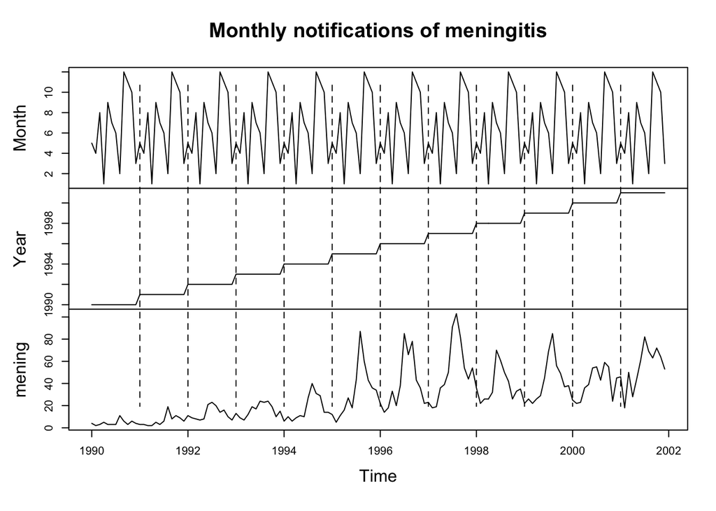

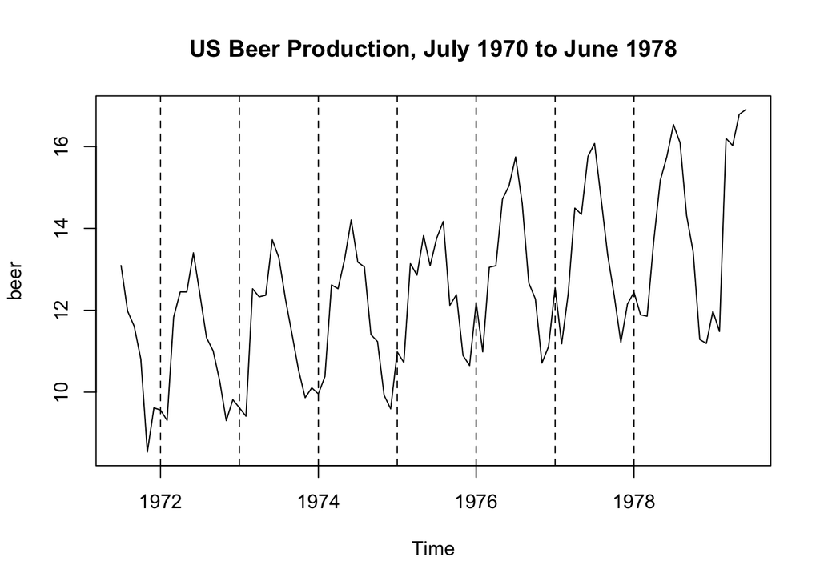

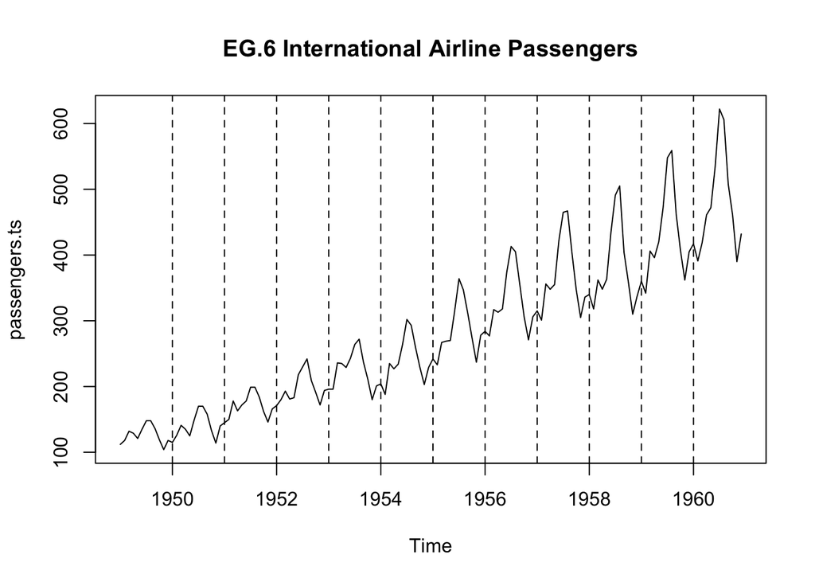

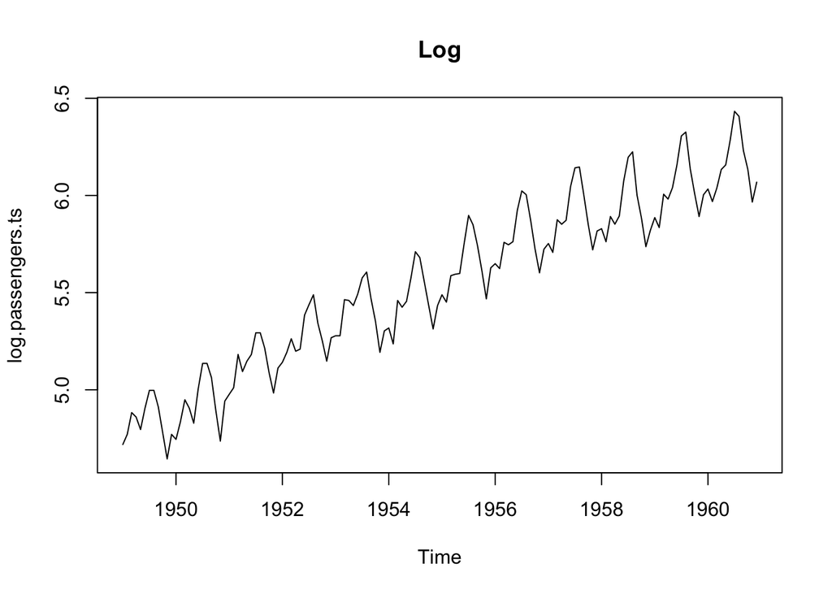

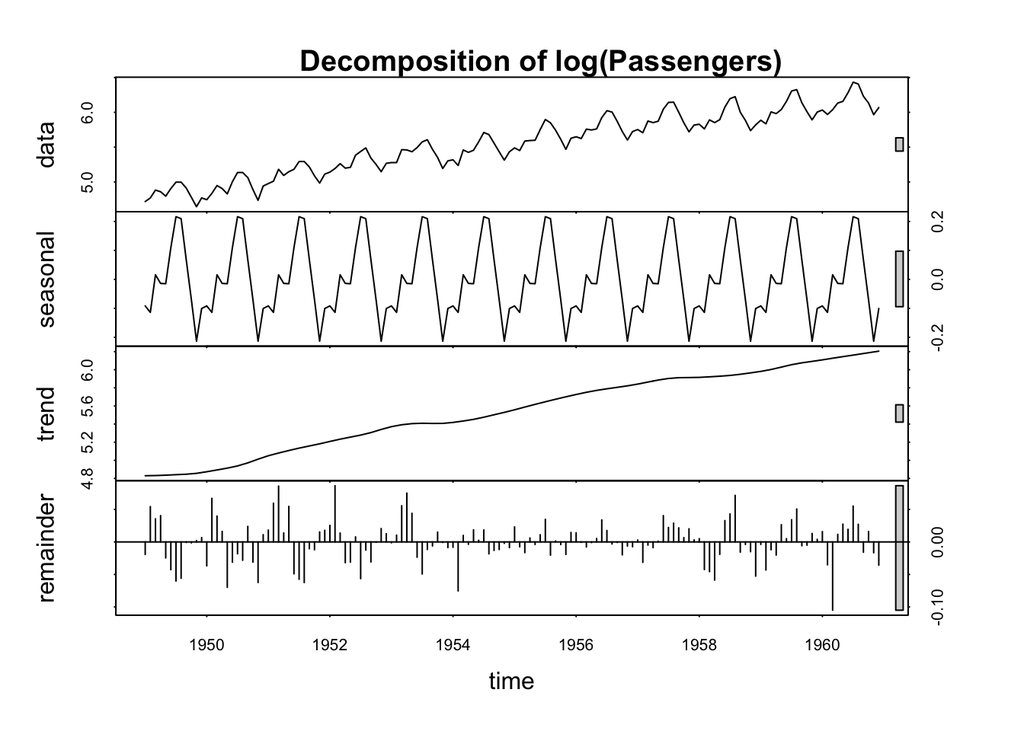

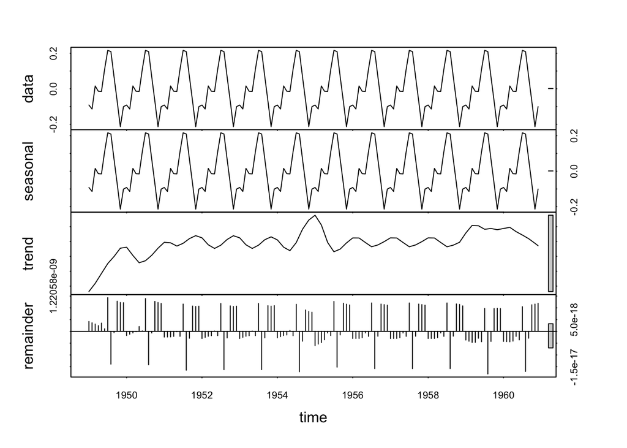

- 季节性和循环的区别：
  - 循环：其周期和振幅都是不固定且不能预测的。
  - 季节性是有相等间隔的有规律重复的模型。